# Hiper Parametrización 2 - La venganza

Alejandro Bolaños

2019-10-21

> … premature optimization is the root of all evil — Donald Knuth

> Success is a lousy teacher. It seduces smart people into thinking they can’t lose. — Bill Gates

En este notebook nos empaparemos con detalles de la hiperparametrización con el resultado de las optimizaciones. Primero veremos rapidamente como funciona la optimización bayesiana con dos ejemplos, ya utilizando la librería mlrMBO, que nos dan muchas más opciones que la que veníamos usando:

```r
rm( list=ls() )
gc()
```

```
##          used (Mb) gc trigger (Mb) max used (Mb)
## Ncells 510322 27.3    1147230 61.3   621665 33.3
## Vcells 974538  7.5    8388608 64.0  1600562 12.3
```

```r
library(ggplot2)
library(mlrMBO)
configureMlr(show.learner.output = FALSE)
set.seed(1)

obj.fun = makeSingleObjectiveFunction(
  name = "Sine",
  fn = function(x) sin(x),
  par.set = makeNumericParamSet(lower = 3, upper = 13, len = 1),
  global.opt.value = -1
)

ctrl = makeMBOControl(propose.points = 1)
ctrl = setMBOControlTermination(ctrl, iters = 10L)
ctrl = setMBOControlInfill(ctrl, crit = makeMBOInfillCritEI(),
                           opt = "focussearch", opt.focussearch.points = 500L)

lrn = makeMBOLearner(ctrl, obj.fun)

design = generateDesign(6L, getParamSet(obj.fun), fun = lhs::maximinLHS)

run = exampleRun(obj.fun, design = design, learner = lrn,
                 control = ctrl, points.per.dim = 100, show.info = TRUE)
```

```
## Evaluating true objective function at 100 points.
```

```
## Performing MBO on function.
```

```
## Learner: regr.km. Settings:
## jitter=FALSE,covtype=matern3_2,optim.method=gen,nugget.stability=1e-08
```

```
## Computing y column(s) for design. Not provided.
```

```
## [mbo] 0: x=9.2 : y = 0.227 : 0.0 secs : initdesign
```

```
## [mbo] 0: x=7.99 : y = 0.991 : 0.0 secs : initdesign
```

```
## [mbo] 0: x=12 : y = -0.564 : 0.0 secs : initdesign
```

```
## [mbo] 0: x=4.3 : y = -0.914 : 0.0 secs : initdesign
```

```
## [mbo] 0: x=11.2 : y = -0.974 : 0.0 secs : initdesign
```

```
## [mbo] 0: x=5.02 : y = -0.953 : 0.0 secs : initdesign
```

```
## [mbo] 1: x=3 : y = 0.141 : 0.0 secs : infill_ei
```

```
## [mbo] 2: x=4.67 : y = -0.999 : 0.0 secs : infill_ei
```

```
## [mbo] 3: x=10.8 : y = -0.971 : 0.0 secs : infill_ei
```

```
## [mbo] 4: x=11 : y = -1 : 0.0 secs : infill_ei
```

```
## [mbo] 5: x=4.8 : y = -0.996 : 0.0 secs : infill_ei
```

```
## [mbo] 6: x=13 : y = 0.42 : 0.0 secs : infill_ei
```

```
## [mbo] 7: x=10.9 : y = -0.996 : 0.0 secs : infill_ei
```

```
## [mbo] 8: x=4.56 : y = -0.989 : 0.0 secs : infill_ei
```

```
## [mbo] 9: x=11.1 : y = -0.997 : 0.0 secs : infill_ei
```

```
## [mbo] 10: x=4.73 : y = -1 : 0.0 secs : infill_ei
```

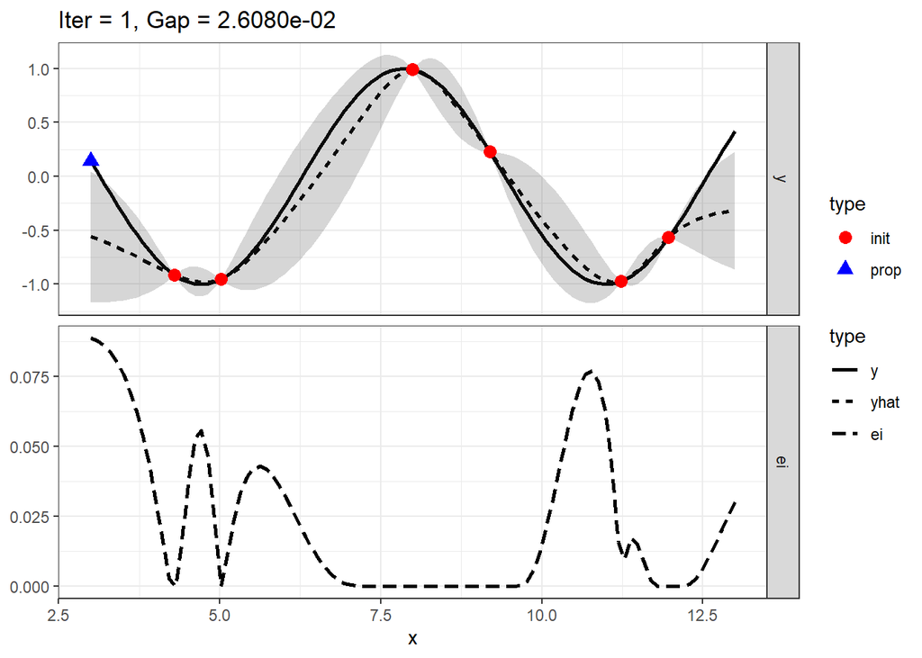

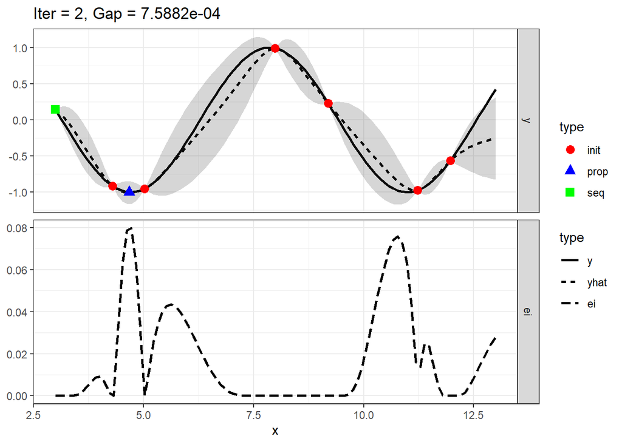

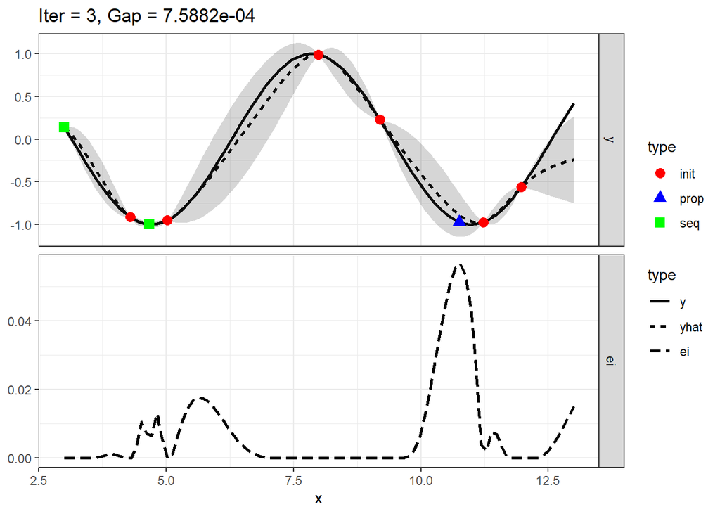

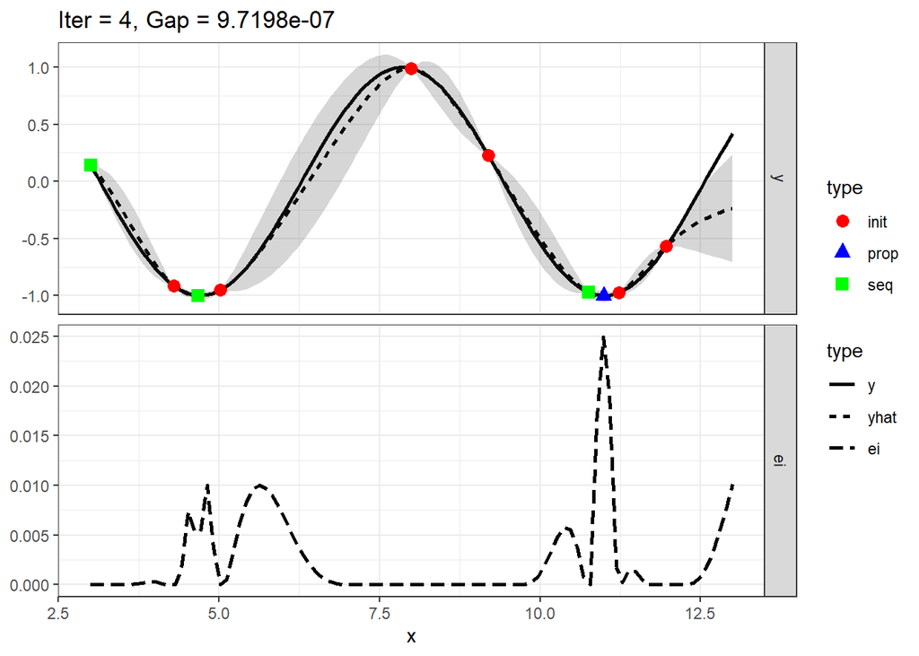

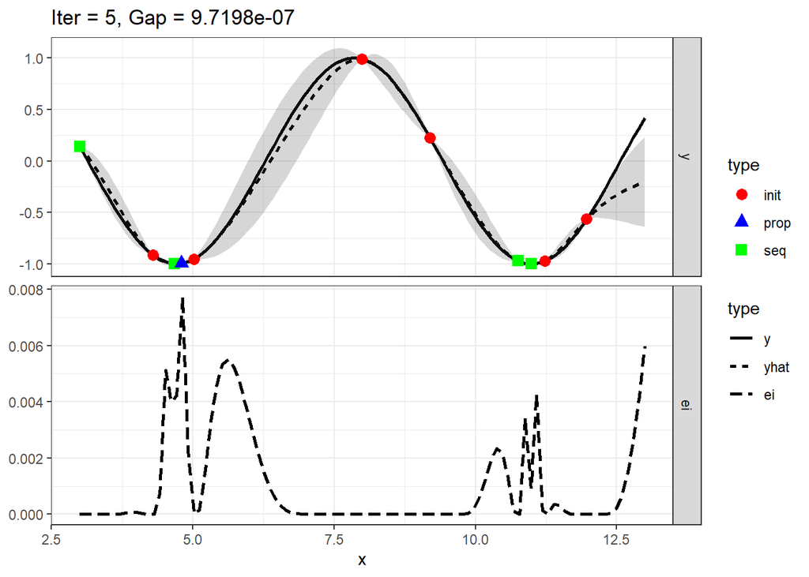

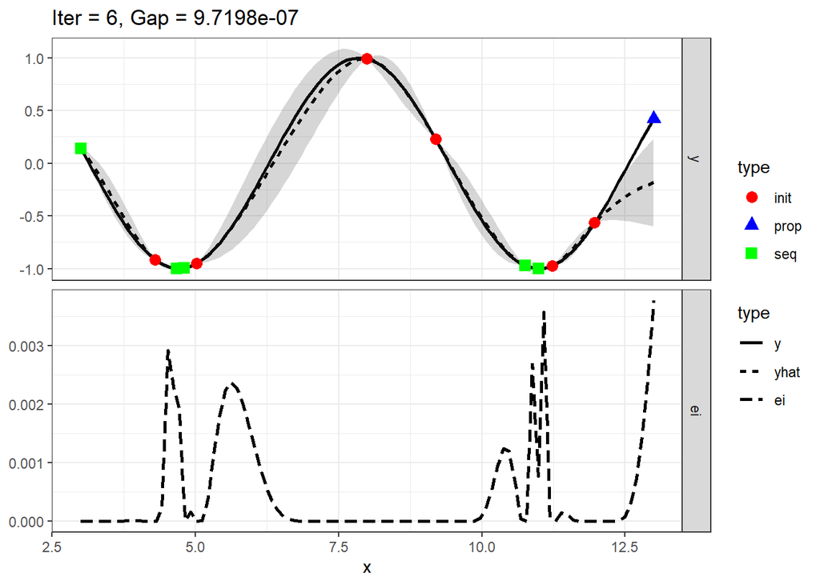

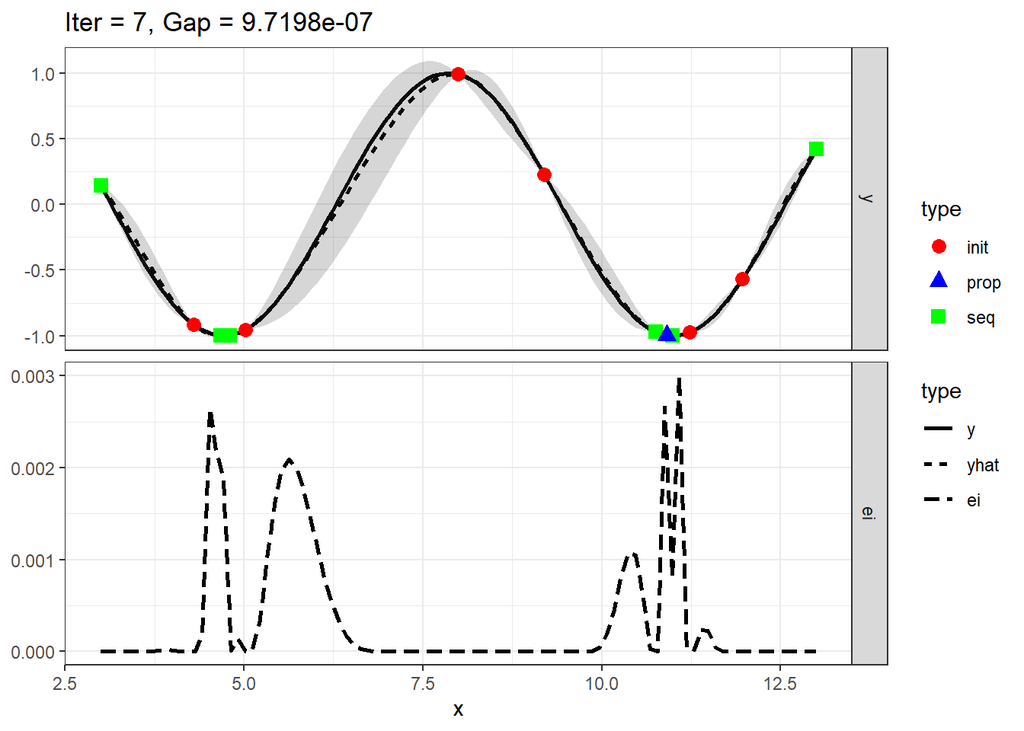

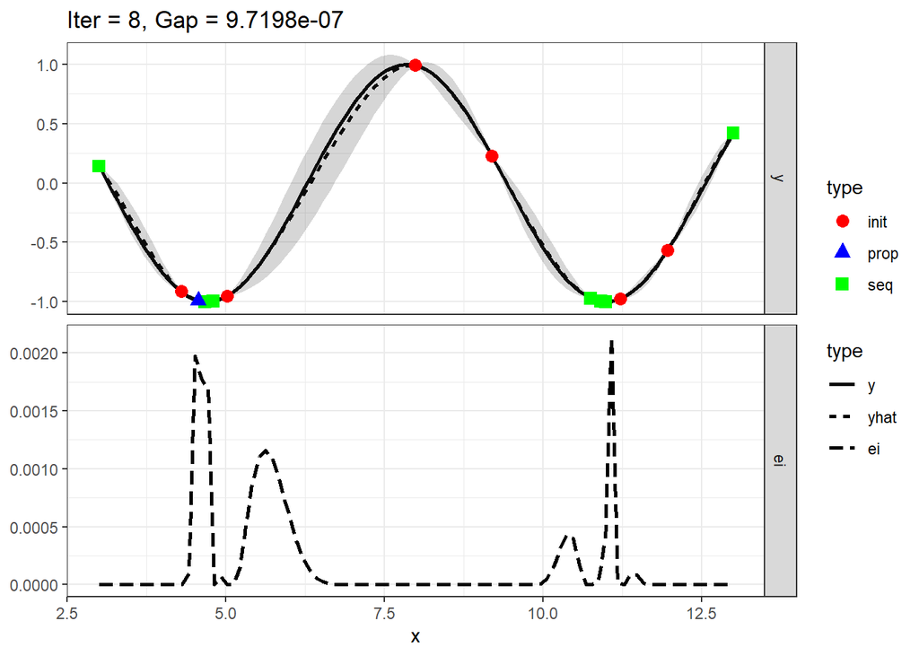

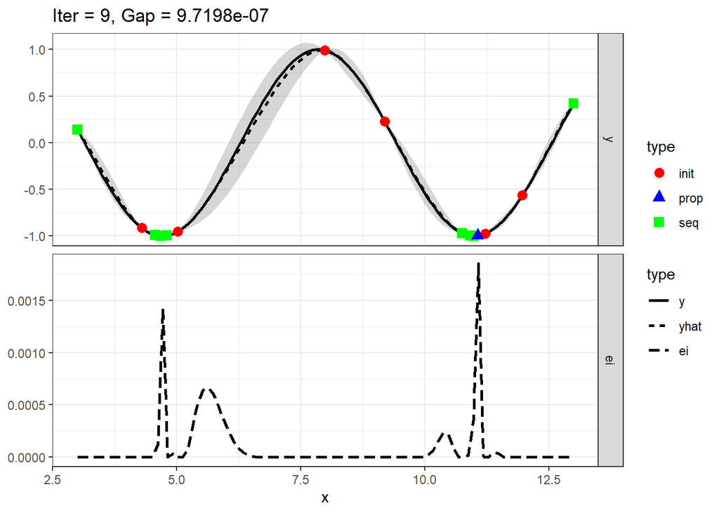

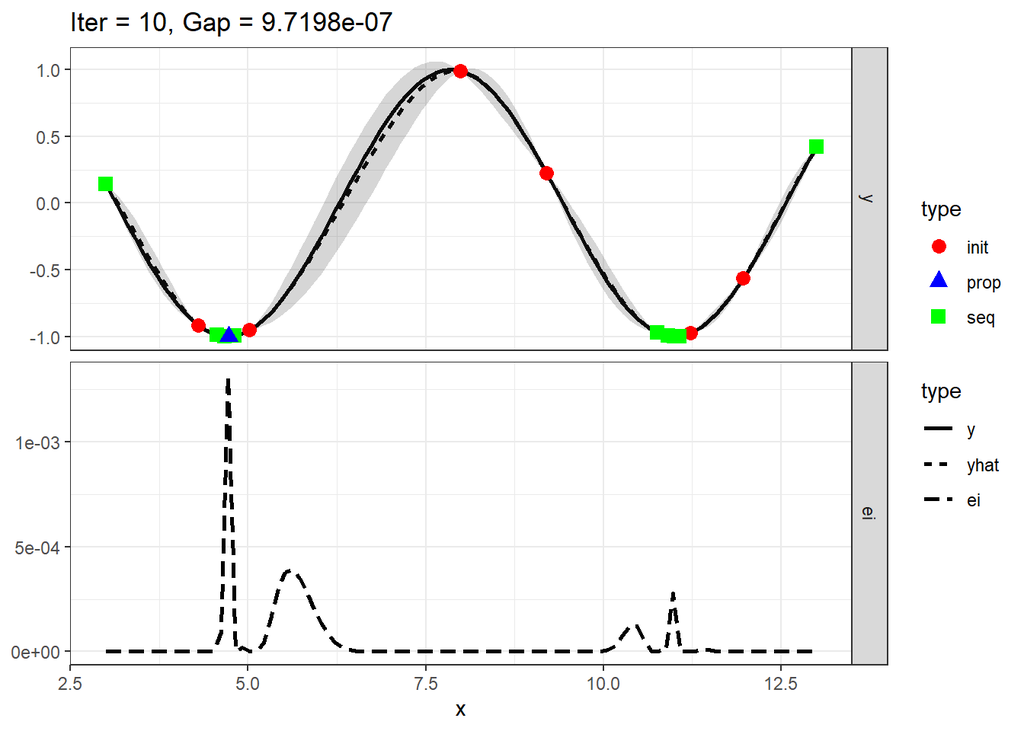

```r
plotExampleRun(run, densregion = TRUE, gg.objects = list(theme_bw()), pause = FALSE)
```

```r
set.seed(1)
configureMlr(show.learner.output = FALSE)

obj.fun = makeBraninFunction()

ctrl = makeMBOControl(propose.points = 1L)
ctrl = setMBOControlTermination(ctrl, iters = 10L)
ctrl = setMBOControlInfill(ctrl, crit = makeMBOInfillCritEI(),
                           opt = "focussearch", opt.focussearch.points = 20L)

lrn = makeMBOLearner(ctrl, obj.fun)
design = generateDesign(10L, getParamSet(obj.fun), fun = lhs::maximinLHS)

run = exampleRun(obj.fun, design = design, learner = lrn, control = ctrl,
                 points.per.dim = 50L, show.info = TRUE)
```

```
## Evaluating true objective function at 50 x 50 points.
```

```
## Performing MBO on function.
```

```
## Learner: regr.km. Settings:
## jitter=FALSE,covtype=matern3_2,optim.method=gen,nugget.stability=1e-08
```

```
## Computing y column(s) for design. Not provided.
```

```
## [mbo] 0: x=-2.54,12.4 : y = 4.47 : 0.0 secs : initdesign
```

```
## [mbo] 0: x=6.81,10.5 : y = 105 : 0.0 secs : initdesign
```

```
## [mbo] 0: x=-3.83,6.95 : y = 52.2 : 0.0 secs : initdesign
```

```
## [mbo] 0: x=5.2,7.82 : y = 58 : 0.0 secs : initdesign
```

```
## [mbo] 0: x=3.18,3.19 : y = 1.31 : 0.0 secs : initdesign
```

```
## [mbo] 0: x=0.115,0.717 : y = 45.6 : 0.0 secs : initdesign
```

```
## [mbo] 0: x=8.22,2.89 : y = 8.14 : 0.0 secs : initdesign
```

```
## [mbo] 0: x=1.91,14.4 : y = 127 : 0.0 secs : initdesign
```

```
## [mbo] 0: x=9.48,12 : y = 89.5 : 0.0 secs : initdesign
```

```
## [mbo] 0: x=-1.47,5.6 : y = 20.1 : 0.0 secs : initdesign
```

```
## [mbo] 1: x=5.43,3.55 : y = 22 : 0.0 secs : infill_ei
```

```
## [mbo] 2: x=-0.499,2.84 : y = 34.3 : 0.0 secs : infill_ei
```

```
## [mbo] 3: x=9.12,0.0722 : y = 5.5 : 0.0 secs : infill_ei
```

```
## [mbo] 4: x=-4.86,15 : y = 14.6 : 0.0 secs : infill_ei
```

```
## [mbo] 5: x=3.92,0.612 : y = 4.43 : 0.0 secs : infill_ei
```

```
## [mbo] 6: x=-1.82,10.1 : y = 8.22 : 0.0 secs : infill_ei
```

```
## [mbo] 7: x=7.8,0.0213 : y = 12.5 : 0.0 secs : infill_ei
```

```
## [mbo] 8: x=10,2.19 : y = 2.59 : 0.0 secs : infill_ei
```

```
## [mbo] 9: x=-2.86,15 : y = 12.3 : 0.0 secs : infill_ei
```

```
## [mbo] 10: x=9.27,1.81 : y = 0.802 : 0.0 secs : infill_ei
```

```r
print(run)
```

```
## MBOExampleRun
## Number of parameters        : 2
## Parameter names             : x1,x2
## Parameter types             : numericvector
## Global Opt (known)          : 3.9789e-01
## Gap for best point          : 4.0413e-01
## True points per dim.        : 50
## Objectives                    : 1
## Points proposed per iter      : 1
##
## Infill criterion            : Expected improvement (ei)
##   Direction of optimization : maximize
##   Requirement               : SE estimation
##   Components                : se, mean
##   Parameters                : se.threshold=1e-06
## Infill optimizer              : focussearch
## Infill optimizer restarts     : 1
## Final point by                : best.true.y
## Learner                     : regr.km
## Learner settings:
## jitter=FALSE,covtype=matern3_2,optim.method=gen,nugget.stability=1e-08
## Recommended parameters:
## x=9.27,1.81
## Objective: y = 8.020e-01
```

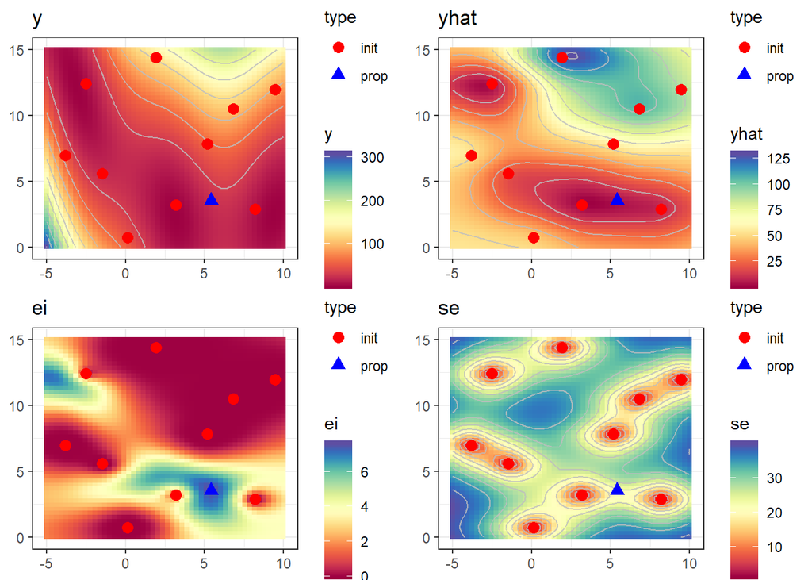

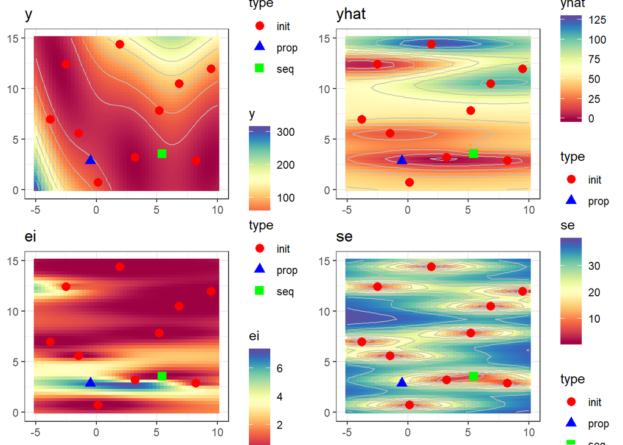

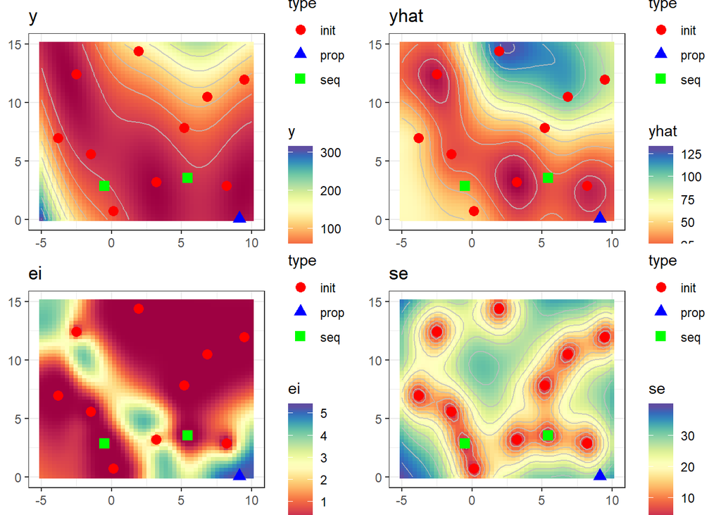

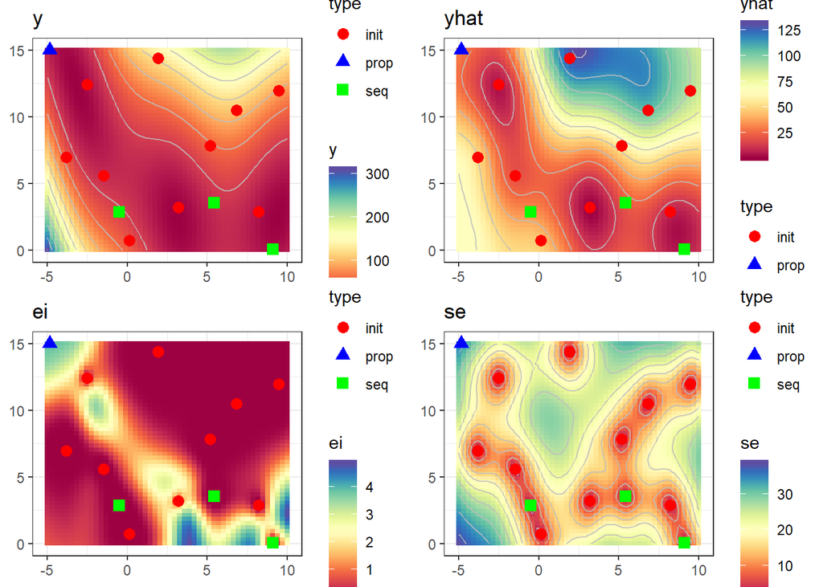

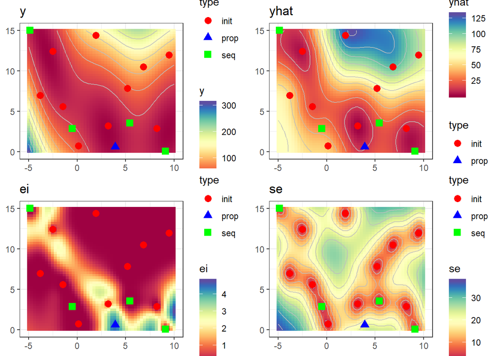

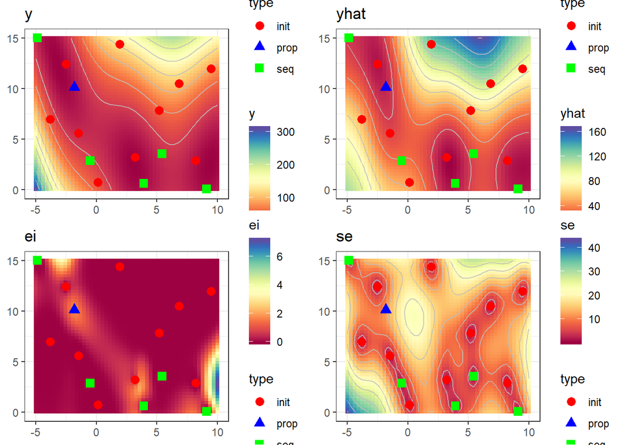

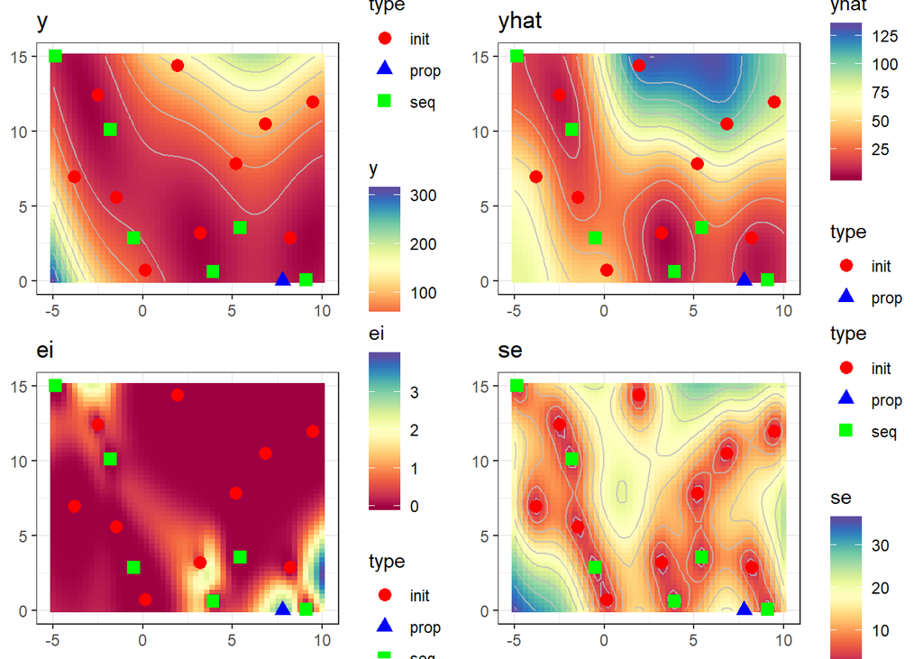

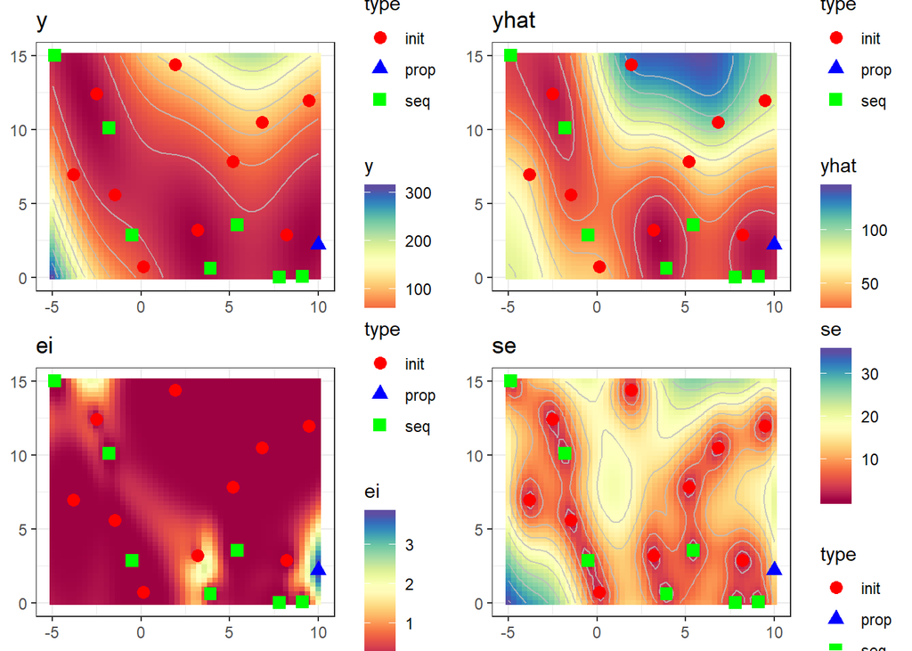

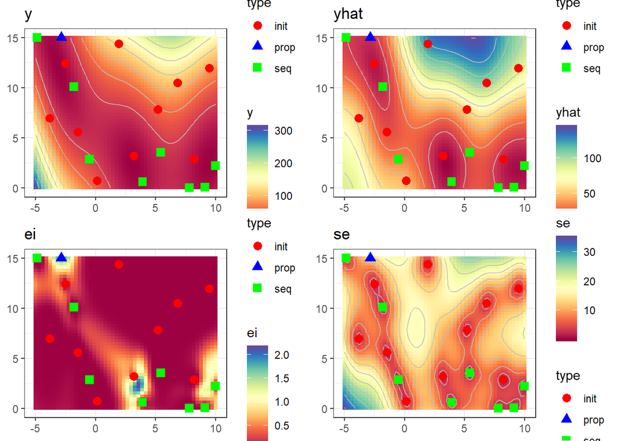

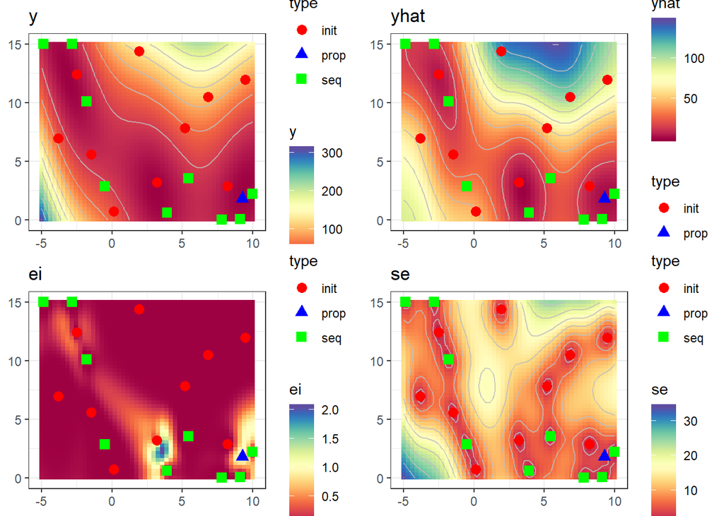

```r
plotExampleRun(run, gg.objects = list(theme_bw()), pause = FALSE)
```

Algunos links que pueden ser de algún interés:

- https://www.kdnuggets.com/2018/10/intuitions-behind-bayesian-optimization-gaussian-processes.html
- http://mlrmbo.mlr-org.com/articles/mlrMBO.html

Vamos a analizar de una forma similar nuestra objetivo, cargando previamente las funciones auxiliares para poder trabajar más cómodos:

```r
library( "data.table" )
vsemillas <- c(810757,482071,340979,446441,917513)

periodo_delta <- function (foto_mes, delta) {

  len <-2

  step_cant <- delta

  step <- paste0(step_cant, " months")

  resultado <-  as.integer(strftime(seq(
    as.Date(paste0(foto_mes, "01"), format = "%Y%m%d"),
    length = len,
    by = step
  ), format = "%Y%m"))

  return(resultado[2])

  }

periodos_delta_serie <- function (foto_mes, delta) {
  sapply(0:(delta), periodo_delta, foto_mes=foto_mes)
}
```

A la carga del mes le vamos a sacar la carga de las nuevas clases, simplemente queremos trabajar con la búsqueda de parámetros en su estado más simple, prediciendo solamente la clase `BAJA+2`

```r
cargar_meses <- function(foto_mes, diferencia) {
  dataset_list <- list()
  clases_vector <- c()

  for (fm in periodos_delta_serie(foto_mes, diferencia)) {
    dataset_mes <- readRDS(paste0("../datasets/dias/", fm, ".RDS"))

    clases <- ifelse(dataset_mes[, clase_ternaria] == "BAJA+2", 1, 0)
    dataset_mes[, clase_ternaria := NULL]
    dataset_mes[, numero_de_cliente := NULL]
    dataset_mes[, foto_mes := NULL]

    dataset_list[[as.character(fm)]] <- dataset_mes
    clases_vector <- c(clases_vector, clases)
  }
  resultado <- list()
  resultado[["datos"]] <- rbindlist(dataset_list)
  resultado[["clases"]] <- clases_vector
  resultado
}
```

Y trabajaremos por su velocidad con LightGBM

```r
library(lightgbm)
modelar_lgbm <- function(ds,
           target,
           param = list()) {

  dtrain_lgm <- lgb.Dataset(data.matrix(ds), label = target)

  params <- c(param, list(objective = "binary", metric = "auc"))

  modelo <- lgb.cv(params,
                dtrain_lgm,
                tree_learner="serial",
                25,
                nfold = 5,
                stratified = TRUE,
                verbose = -1)
  modelo
}
```

Y vamos a trabjar con una muestra, para acortar los tiempos de procesamiento:

```r
# Muestrea, quedandose con todos los elementos de la clases y una cantidad
# definida del resto. Devuelve un vector Booleano.

tomar_muestra <- function(datos, resto=10000 ) {
      t <- datos$clases == 1
      r <- rep(FALSE, length(datos$clases))
      r[!t][sample.int(resto,n=(length(datos$clases)-sum(datos$clases)))] <- TRUE
      t | r
}

abril2018 <- cargar_meses(201804,0)
abril2018$muestra <- tomar_muestra(abril2018, resto=20000)

sum(abril2018$clases)
```

```
## [1] 1163
```

```r
sum(abril2018$muestra)
```

```
## [1] 21163
```

```r
t0 <- Sys.time()
m <- modelar_lgbm(abril2018$datos, abril2018$clases)
t1 <- Sys.time()
print(t1-t0)
```

```
## Time difference of 16.54172 secs
```

```r
t0 <- Sys.time()
m <- modelar_lgbm(abril2018$datos[abril2018$muestra], abril2018$clases[abril2018$muestra])
t1 <- Sys.time()
print(t1-t0)
```

```
## Time difference of 4.702287 secs
```

```r
m$best_score
```

```
## [1] 0.9150958
```

Vamos entonces antes de optimizar los parámetros, a explorar, cual grid search, uno de los mismos, para entender en que escenario nos encontramos, buscando el mejor número para `learning_rate`

```r
resultado <- list()
resultado$x <- seq(from = 0.01, to = 1, by = 0.02)
resultado$y <- c()

for (v in resultado$x) {
  resultado$y <-
    c(
      resultado$y,
      modelar_lgbm(
        abril2018$datos[abril2018$muestra],
        abril2018$clases[abril2018$muestra],
        param = list(learning_rate = v)
      )
    )
}

saveRDS(resultado, "resultados/11_res1.RDS")
```

Y hacemos lo que más me gusta, graficar:

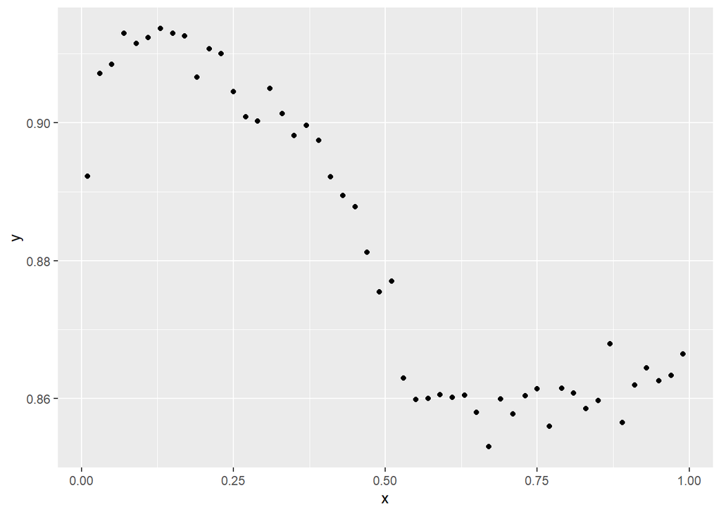

```r
res <- readRDS("resultados/11_res1.RDS")

d <- data.frame(x=res$x , y=sapply(res$y, function(x) x$best_score))

ggplot(d, aes(x,y))  +
  geom_point()
```

Si uno compara con los ejemplos anteriores, creo que la principal diferencia que uno encuentra es la fuerte presencia de ruido. Recordando la no menor referencia, de que lo que hicimos fue un `CV`. O sea, los puntos anteriores se vieron suavizados por la media de varias iteraciones!!!

Buscamos el punto máximo:

```r
max(d$y)
```

```
## [1] 0.9136703
```

```r
d$x[which.max(d$y)]
```

```
## [1] 0.13
```

Aún así el máximo que nos ofrece nos convence (gráficamente). Para el resultado anterior tuvimos que calcular 50 puntos, veamos si **BO** nos ayuda:

```r
set.seed(vsemillas[1])

obj.fun = makeSingleObjectiveFunction(
  name = "learning_rate",
  fn = function(x)
    - modelar_lgbm(
      abril2018$datos[abril2018$muestra],
      abril2018$clases[abril2018$muestra],
      param = list(learning_rate = x)
    )$best_score,
  par.set = makeNumericParamSet(lower = 0.01, upper = 1),
  has.simple.signature = FALSE,
  global.opt.value = -1
)

ctrl = makeMBOControl(propose.points = 1)
ctrl = setMBOControlTermination(ctrl, iters = 10L)
ctrl = setMBOControlInfill(
  ctrl,
  crit = makeMBOInfillCritEI(),
  opt = "focussearch",
  opt.focussearch.points = 500L
)

lrn = makeMBOLearner(ctrl, obj.fun)
design = generateDesign(5L, getParamSet(obj.fun), fun = lhs::maximinLHS)

surr.km <-
  makeLearner("regr.km", predict.type = "se", covtype = "matern3_2")


run = exampleRun(
  obj.fun,
  design = design,
  learner = surr.km,
  control = ctrl,
  points.per.dim = 25,
  show.info = TRUE
)

saveRDS(run, "resultados/11_res2.RDS")
```

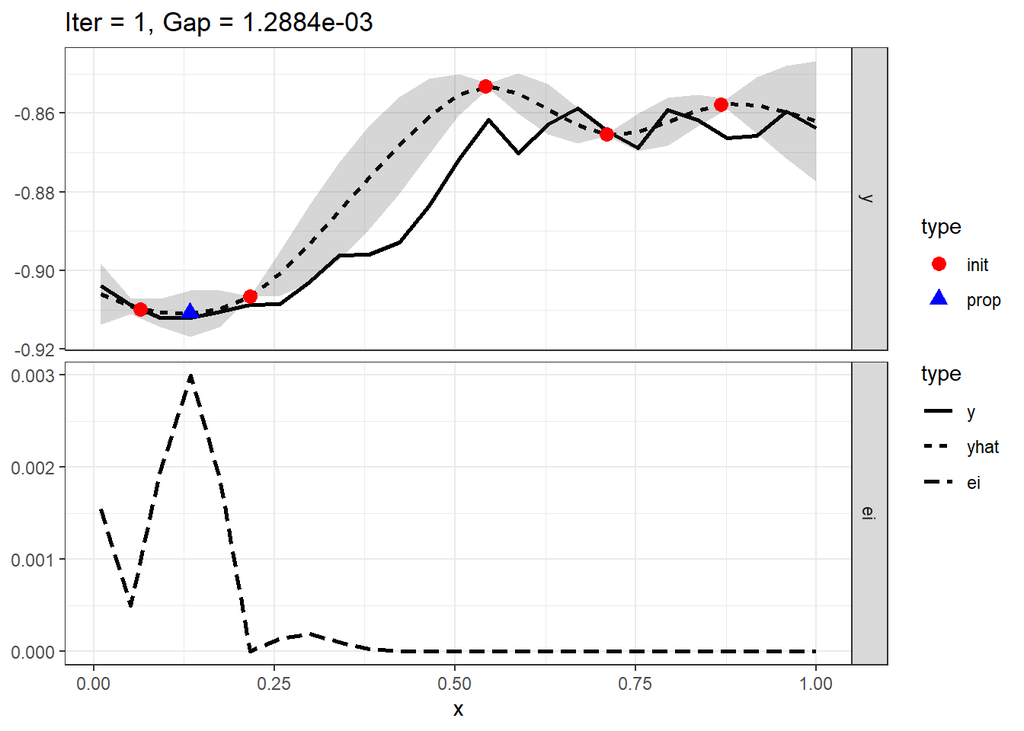

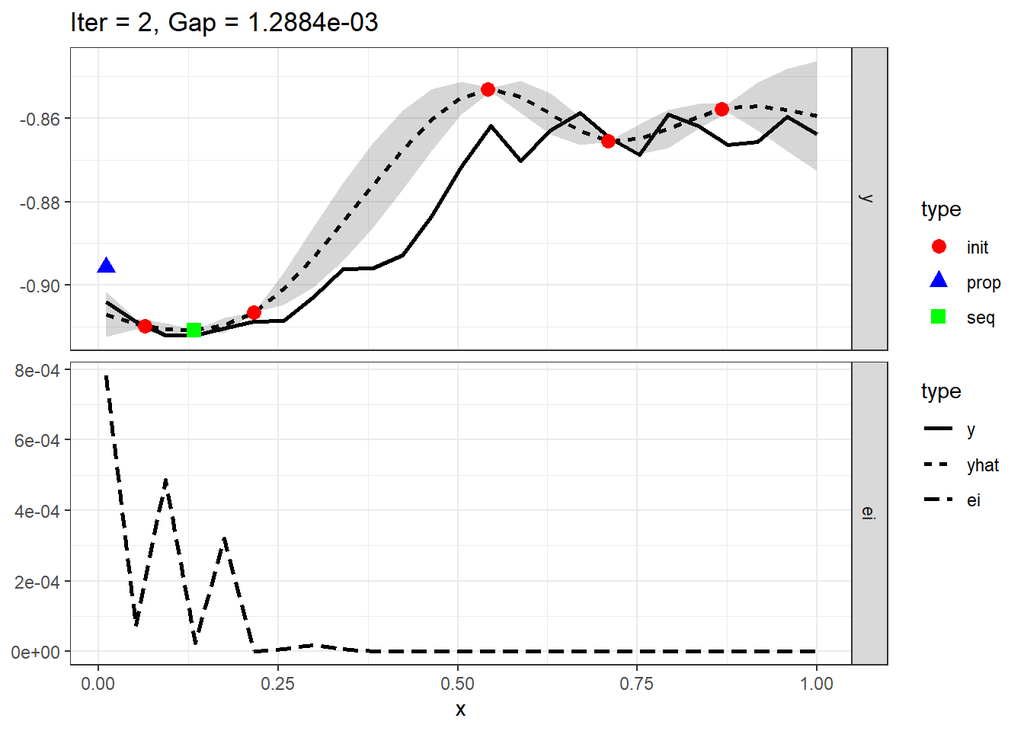

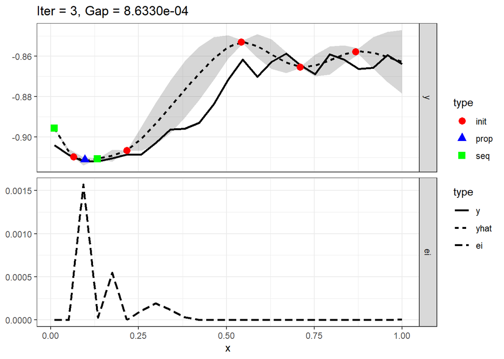

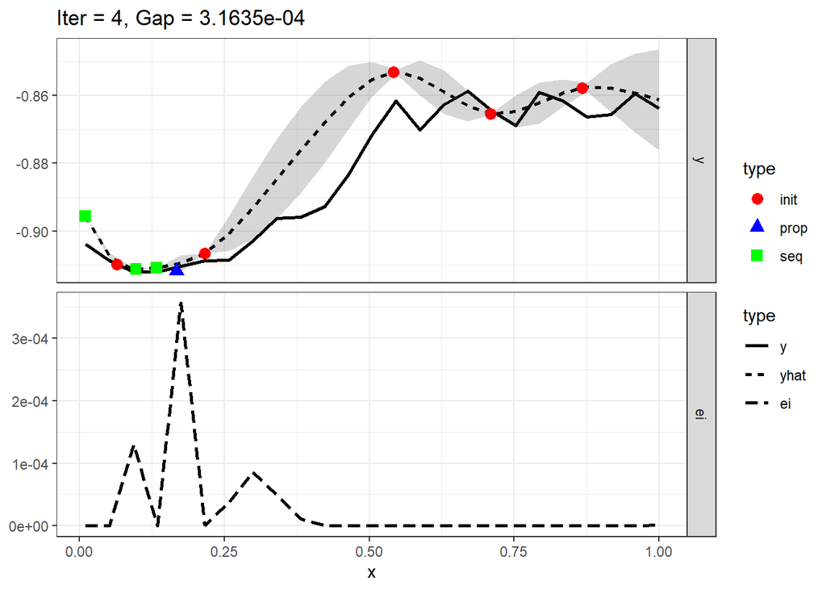

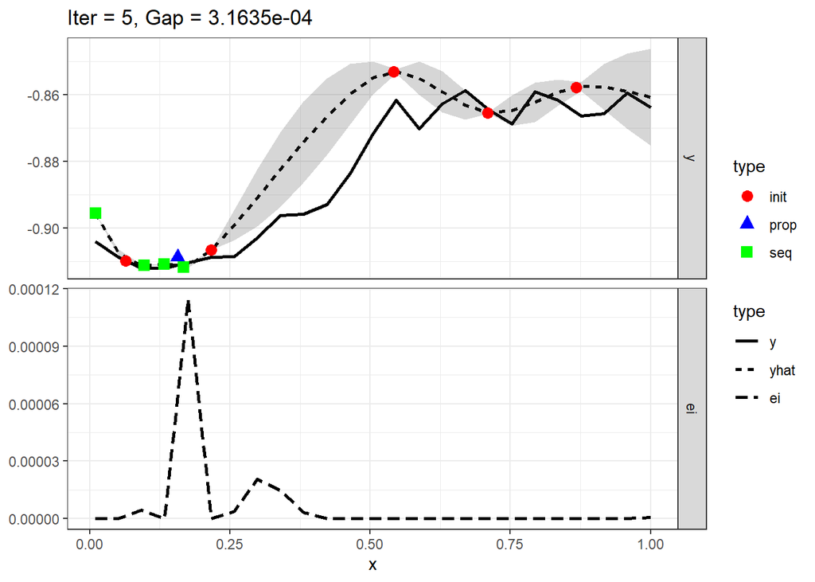

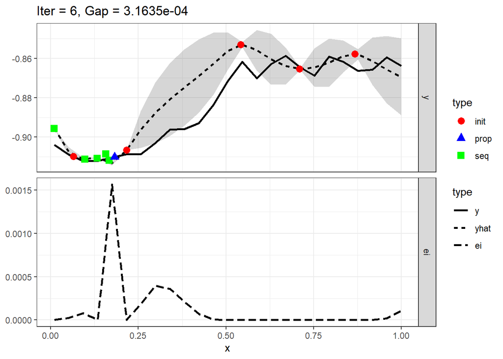

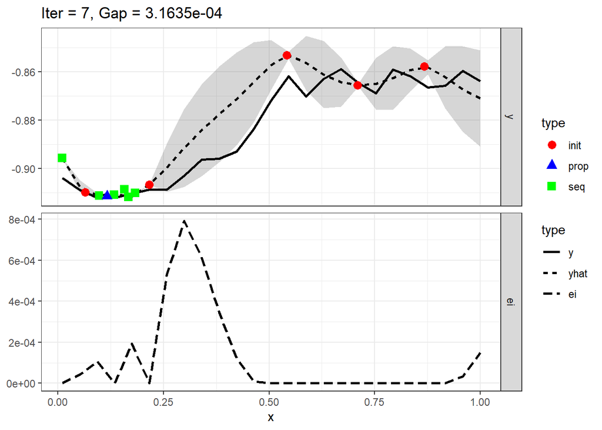

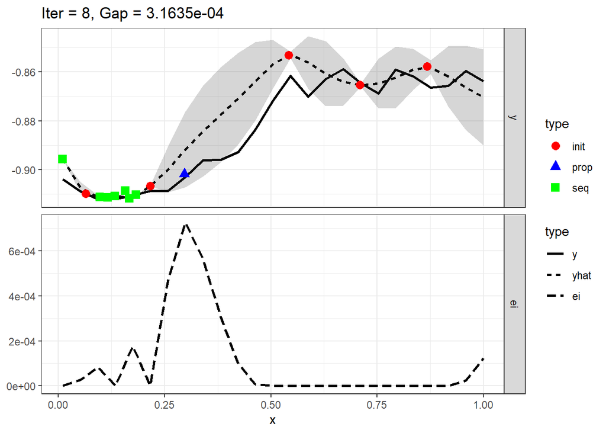

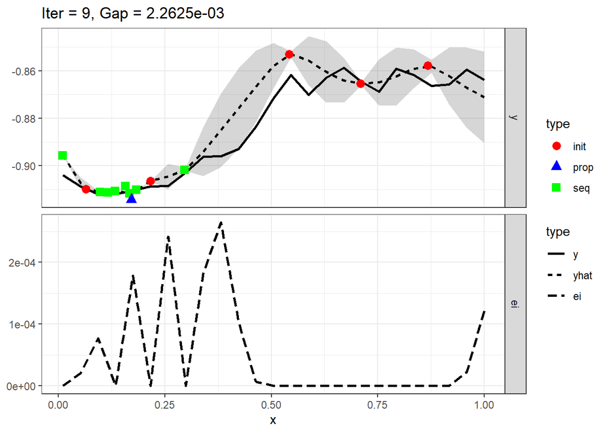

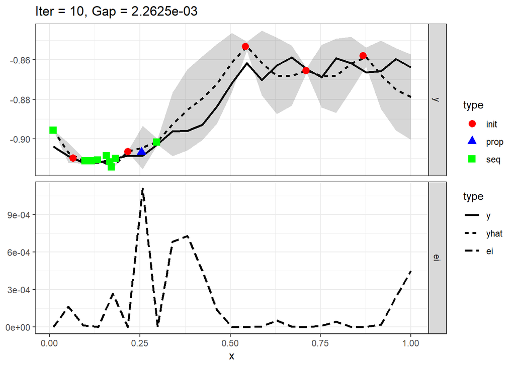

```r
run <- readRDS("resultados/11_res2.RDS")
plotExampleRun(run, densregion = TRUE, gg.objects = list(theme_bw()), pause=FALSE)
```

```r
print(run)
```

```
## MBOExampleRun
## Number of parameters        : 1
## Parameter names             : x
## Parameter types             : numericvector
## Global Opt (estimated)      : -9.1201e-01
## Gap for best point          : NA
## True points per dim.        : 25
## Objectives                    : 1
## Points proposed per iter      : 1
##
## Infill criterion            : Expected improvement (ei)
##   Direction of optimization : maximize
##   Requirement               : SE estimation
##   Components                : se, mean
##   Parameters                : se.threshold=1e-06
## Infill optimizer              : focussearch
## Infill optimizer restarts     : 1
## Final point by                : best.true.y
## Learner                     : regr.km
## Learner settings:
## jitter=FALSE,covtype=matern3_2
## Recommended parameters:
## x=0.171
## Objective: y = -9.143e-01
```

Podemos probar parametrizar otras forma la búsqueda, hay opciones para trabajar con ruido, pero dejamos al alumno explorar las mismas, mientras continuamos por esta senda, ya que el resultado devuelto nos parecio bueno.

Repetimos el análisis anterior, pero con otro parámetro, `L2`

```r
resultado <- list()
resultado$x <- seq(from = 0, to = 50, by = 1)
resultado$y <- c()

for (v in resultado$x) {
  resultado$y <-
    c(
      resultado$y,
      modelar_lgbm(
        abril2018$datos[abril2018$muestra],
        abril2018$clases[abril2018$muestra],
        param = list(lambda_l2 = v)
      )
    )
}

saveRDS(resultado, "resultados/11_res3.RDS")
```

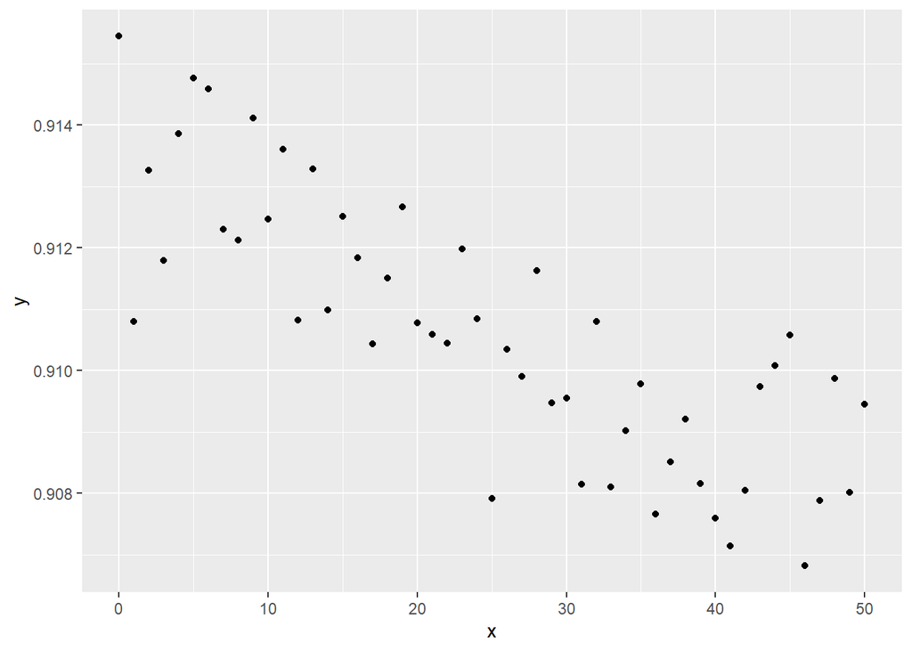

```r
res <- readRDS("resultados/11_res3.RDS")

d <- data.frame(x=res$x , y=sapply(res$y, function(x) x$best_score))

ggplot(d, aes(x,y))  +
  geom_point()
```

Nos encontramos con un parámetros con mucho más ruido.

```r
max(d$y)
```

```
## [1] 0.9154473
```

```r
d$x[which.max(d$y)]
```

```
## [1] 0
```

Cambiando la función objetivo para buscar nuestro nuevo parámetro, aplicamos nuevamente **MBO**:

```r
set.seed(vsemillas[1])

obj.fun = makeSingleObjectiveFunction(
  name = "L2",
  fn = function(x)
    - modelar_lgbm(
      abril2018$datos[abril2018$muestra],
      abril2018$clases[abril2018$muestra],
      param = list(lambda_l2 = x)
    )$best_score,
  par.set = makeNumericParamSet(lower = 0.0, upper =  50.0),
  has.simple.signature = FALSE,
  global.opt.value = -1
)

ctrl = makeMBOControl(propose.points = 1)
ctrl = setMBOControlTermination(ctrl, iters = 10L)
ctrl = setMBOControlInfill(
  ctrl,
  crit = makeMBOInfillCritEI(),
  opt = "focussearch",
  opt.focussearch.points = 10L
)

lrn = makeMBOLearner(ctrl, obj.fun)
design = generateDesign(5L, getParamSet(obj.fun), fun = lhs::maximinLHS)

surr.km <-
  makeLearner("regr.km", predict.type = "se", covtype = "matern3_2")

run = exampleRun(
  obj.fun,
  design = design,
  learner = surr.km,
  control = ctrl,
  points.per.dim = 25,
  show.info = TRUE
)

saveRDS(run, "resultados/11_res4.RDS")
```